# Abstractive Text Summarization

In the modern Internet age, textual data is ever increasing. We need some way to condense this data while preserving the information and its meaning. We need to summarise textual data for that. Text summarisation is the process of automatically generating natural language summaries from an input document while retaining the important points. It helps in the easy and fast retrieval of information.

Abstractive summarisation is a type of summarization which includes generating new phrases, possibly rephrasing or using words that were not in the original text.

### Dataset

*Dataset Repo - [News Summary](https://www.kaggle.com/sunnysai12345/news-summary)*

[output not shown]

### Apporach:

Naturally abstractive approaches are harder. For a perfect abstractive summary, the model has to first truly understand the document and then try to express that understanding in shortform, possibly using new words and phrases.

This is much harder than an extractive summary, requiring complex capabilities like generalisation, paraphrasing and incorporating real-world knowledge. So, to achieve best in class outcomes for the above mentioned task, we are going to fine-tune transformer models.

Transformer is an architecture for transforming one sequence into another one with the help of two parts (Encoder and Decoder), but it differs from the traditional sequence-to-sequence models because it does not imply any Recurrent Networks (GRU, LSTM, etc.).

To understand more about transformers [click here.](https://huggingface.co/transformers/)

### Choice of Transformers

We are going to fine-tune two transformers and select the best performing model for summarization.

> **Google’s T5(Text-To-Text Transfer Transformer):** T5 is an encoder-decoder model pre-trained on a multi-task mixture of unsupervised and supervised tasks and for which each task is converted into a text-to-text format. T5 works well on a variety of tasks out-of-the-box by prepending a different prefix to the input corresponding to each task, e.g.: For translation: Translate English to German.  
> **Facebook’s Bart:** BART is a denoising autoencoder that maps a corrupted document to the original document it was derived from. It is implemented as a sequence-to-sequence model with a bidirectional encoder over corrupted text and a left-to-right autoregressive decoder.

### Performance Evaluation Metrics

In the scope of this experiment, we have adopted only content-based methods to measure the performance of summarizer. One of the metric is rouge score.

**Rouge Score:** ROUGE stands for Recall-Oriented Understudy for Gisting Evaluation. It is essentially a set of metrics for evaluating automatic summarisation of texts as well as machine translation. It works by comparing an automatically produced summary or translation against a set of reference summaries (typically human-produced).

It is further divided into different measures depending upon the granularity. More details can be found here

> **Rouge-1** - It refers to overlap of unigrams between the system summary and reference summary.  
> **Rouge-2** - It refers to the overlap of bigrams between the system and reference summaries.  
> **Rouge-L** – It measures longest matching sequence of words using LCS.

### Technologies

- **Programming language**
- **Libraries**

[figure not shown]

#### Models Performance

| Model | Rouge-1 | Rouge-2 | Rouge-l |
| --- | --- | --- | --- |
| T5 | 0.453173 | 0.232103 | 0.418052 |
| Bart | 0.431542 | 0.208504 | 0.398183 |

1. **Environment Setup**
   - 1.1 - **Install Package**
   - 1.2 - **Load Dependencies**
2. **Load dataset**
3. **Data Preprocessing**
   - 3.1 - **Data Cleaning**
   - 3.2 - **Build Dataset Class**
   - 3.3 - **Build Lightining Data Module**
4. **Model Development**
   - 4.1. - **T5 Transformer**
   - 4.2. - **Bart Tranformer**
5. **Model Comparision**

## 1. Environment Setup

goto toc

### 1.1. Install Packages

Install required packages

goto toc

```python
!pip install --quiet transformers==4.5.0
!pip install --quiet pytorch-lightning==1.2.7
!pip install --quiet rouge
```

[output not shown]

### 1.2. Load Dependencies

Import required packages

goto toc

```python
import os
import torch
import numpy as np
import pandas as pd
import seaborn as sns
from rouge import Rouge
from pathlib import Path
from tqdm.auto import tqdm
from termcolor import colored
import pytorch_lightning as pl
from transformers import AdamW
import matplotlib.pyplot as plt
from torch.utils.data import Dataset, DataLoader
from sklearn.model_selection import train_test_split
from pytorch_lightning.callbacks import ModelCheckpoint
from pytorch_lightning.loggers import TensorBoardLogger
from transformers import T5ForConditionalGeneration, T5TokenizerFast
from transformers import BartForConditionalGeneration, BartTokenizerFast

# Display plot inline
%matplotlib inline
sns.set()

# Set pytorch-lightning seed
pl.seed_everything(42)

if torch.cuda.is_available():
  print('__CUDNN VERSION:', torch.backends.cudnn.version())
  print('__Number CUDA Devices:', torch.cuda.device_count())
  print('Active CUDA Device: GPU', torch.cuda.current_device())
  print('Available devices ', torch.cuda.device_count())
  print('Current cuda device ', torch.cuda.current_device())
```

```
Global seed set to 42
```

```
__CUDNN VERSION: 7605
__Number CUDA Devices: 1
Active CUDA Device: GPU 0
Available devices  1
Current cuda device  0
```

```python
# Download dataset from google drive
!gdown --id 17BuuCy6UMTUDMzNSrTSnBvHp_IRoIzj1
```

```
Downloading...
From: https://drive.google.com/uc?id=17BuuCy6UMTUDMzNSrTSnBvHp_IRoIzj1
To: /content/news_summary.csv
11.9MB [00:00, 72.8MB/s]
```

```python
## Create a config class

class config:
  num_workers = os.cpu_count()
  n_epochs = 3
  batch_size = 8

  text_token_max_length = 512
  summary_token_max_length = 128

  learning_rate = 0.0001
```

## 2. Load dataset

Read data from news_summary.csv file using pandas method read_csv().

goto toc

```python
# Read dataset using pandas
raw_data = pd.read_csv('./news_summary.csv', encoding='latin-1')
raw_data.head()
```

|  | author | date | headlines | read_more | text | ctext |
| --- | --- | --- | --- | --- | --- | --- |
| 0 | Chhavi Tyagi | 03 Aug 2017,Thursday | Daman & Diu revokes mandatory Rakshabandhan in... | http://www.hindustantimes.com/india-news/raksh... | The Administration of Union Territory Daman an... | The Daman and Diu administration on Wednesday ... |
| 1 | Daisy Mowke | 03 Aug 2017,Thursday | Malaika slams user who trolled her for 'divorc... | http://www.hindustantimes.com/bollywood/malaik... | Malaika Arora slammed an Instagram user who tr... | From her special numbers to TV?appearances, Bo... |
| 2 | Arshiya Chopra | 03 Aug 2017,Thursday | 'Virgin' now corrected to 'Unmarried' in IGIMS... | http://www.hindustantimes.com/patna/bihar-igim... | The Indira Gandhi Institute of Medical Science... | The Indira Gandhi Institute of Medical Science... |
| 3 | Sumedha Sehra | 03 Aug 2017,Thursday | Aaj aapne pakad liya: LeT man Dujana before be... | http://indiatoday.intoday.in/story/abu-dujana-... | Lashkar-e-Taiba's Kashmir commander Abu Dujana... | Lashkar-e-Taiba's Kashmir commander Abu Dujana... |
| 4 | Aarushi Maheshwari | 03 Aug 2017,Thursday | Hotel staff to get training to spot signs of s... | http://indiatoday.intoday.in/story/sex-traffic... | Hotels in Maharashtra will train their staff t... | Hotels in Mumbai and other Indian cities are t... |

**Note:** We only need *ctext* and *text* so will drop other features.

## 3. Data Preprocessing

...goto toc

### 3.1. Data Cleaning

...goto toc

```python
# Select required columns
data = raw_data[['ctext', 'text']]

# Rename columns
data.columns = ['text', 'summary']
```

```python
# Function to get missing values
def get_missing(data):

    # Create the dataframe
    missing_values = pd.DataFrame()

    # Get list of all columns
    missing_values['Features'] = data.columns.values

    # get the count of missing values
    missing_values['Count'] = data.isnull().sum().values

    # Calculate percentage of missing values
    percentage = data.isna().mean()*100
    missing_values['Percentange'] = percentage.values

    # return the dataframe
    return missing_values
```

```python
# Function to plot missing values
def plot_missing(missing_values):
    # Plot missing values

    # Get list of features
    columns = missing_values.Features.values.tolist()

    # Get index's
    ind = missing_values.index.to_list()

    # Create subplots
    fig, ax = plt.subplots(1,figsize=(18, 6))

    # Plot missing values based on count
    rects = ax.barh(ind, missing_values.Count.values.tolist(), color='lightblue')
    ax.set_yticks(ind)
    ax.set_yticklabels(columns, rotation='horizontal')
    ax.set_xlabel("Count of missing values")
    ax.set_title("Variables with missing values")
```

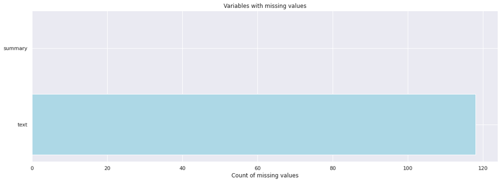

```python
plot_missing(get_missing(data))
```

```python
# Drop missing values
data = data.dropna()
data.head()
```

|  | text | summary |
| --- | --- | --- |
| 0 | The Daman and Diu administration on Wednesday ... | The Administration of Union Territory Daman an... |
| 1 | From her special numbers to TV?appearances, Bo... | Malaika Arora slammed an Instagram user who tr... |
| 2 | The Indira Gandhi Institute of Medical Science... | The Indira Gandhi Institute of Medical Science... |
| 3 | Lashkar-e-Taiba's Kashmir commander Abu Dujana... | Lashkar-e-Taiba's Kashmir commander Abu Dujana... |
| 4 | Hotels in Mumbai and other Indian cities are t... | Hotels in Maharashtra will train their staff t... |

```python
# Split dataset into train and validation set
train_df, val_df = train_test_split(data, test_size = 0.1)

print(train_df.shape)
print(val_df.shape)
```

```
(3956, 2)
(440, 2)
```

### 3.2. Build Dataset Class

...goto toc

```python
class NewsSummaryDataset(Dataset):
    def __init__(self,
                 data : pd.DataFrame,
                 tokenizer,
                 text_max_token_len : int = config.text_token_max_length,
                 summary_max_token_len : int = config.summary_token_max_length):

      self.tokenizer = tokenizer
      self.data = data
      self.text_max_token_len = text_max_token_len
      self.summary_max_token_len = summary_max_token_len

    def __len__(self):
        return len(self.data)

    def __getitem__(self, index : int):
        data_row = self.data.iloc[index]



        # Encode text
        text = data_row['text']
        text_encoding = self.tokenizer(text,
                                      max_length = self.text_max_token_len,
                                      padding = "max_length",
                                      truncation = True,
                                      return_attention_mask = True,
                                      add_special_tokens = True,
                                      return_tensors = "pt")



        # Encode summary
        summary = data_row['summary']
        summary_encoding = self.tokenizer(summary,
                                      max_length = self.summary_max_token_len,
                                      padding = "max_length",
                                      truncation = True,
                                      return_attention_mask = True,
                                      add_special_tokens = True,
                                      return_tensors = "pt")

        # Replace 0's with -100 to let the transformer understand
        labels = summary_encoding['input_ids']
        labels[labels == 0] = -100

        return dict(
            text = text,
            summary = summary,
            text_input_ids = text_encoding['input_ids'].flatten(),
            text_attention_mask = text_encoding['attention_mask'].flatten(),
            labels = labels.flatten(),
            labels_attention_mask = summary_encoding['attention_mask'].flatten()
        )
```

### 3.3. Build Lightining Data Module

...goto toc

```python
class NewsSummaryDataModule(pl.LightningDataModule):
    def __init__(self,
                 train_df: pd.DataFrame,
                 val_df : pd.DataFrame,
                 tokenizer,
                 batch_size: int = config.batch_size,
                 text_max_token_len : int = config.text_token_max_length,
                 summary_max_token_len : int = config.summary_token_max_length
                 ):

        super().__init__()

        self.train_df = train_df
        self.test_df = val_df

        self.tokenizer = tokenizer
        self.batch_size = batch_size

        self.text_max_token_len = text_max_token_len
        self.summary_max_token_len = summary_max_token_len

    def setup(self, stage = None):

        # Build train dataset from custom dataset
        self.train_dataset = NewsSummaryDataset(
            self.train_df,
            self.tokenizer,
            self.text_max_token_len,
            self.summary_max_token_len
        )

        # Build validation dataset from custom dataset
        self.test_dataset = NewsSummaryDataset(
            self.test_df,
            self.tokenizer,
            self.text_max_token_len,
            self.summary_max_token_len
        )

    def train_dataloader(self):
        # Convert dataset to dataloader and return
        return DataLoader(self.train_dataset,
                          batch_size = self.batch_size,
                          shuffle = True,
                          num_workers = config.num_workers)

    def val_dataloader(self):
        # Convert dataset to dataloader and return
        return DataLoader(self.test_dataset,
                          batch_size = self.batch_size,
                          shuffle = False,
                          num_workers = config.num_workers)

    def test_dataloader(self):
        # Convert dataset to dataloader and return
        return DataLoader(self.test_dataset,
                          batch_size = self.batch_size,
                          shuffle = False,
                          num_workers = config.num_workers)
```

## 4. Model Development

...goto toc

```python
# General class for summarization
class NewsSummaryModel(pl.LightningModule):
  def __init__(self, model):

    super().__init__()
    self.model = model# T5ForConditionalGeneration.from_pretrained(MODEL_NAME, return_dict = True)

  def forward(self, input_ids, attention_mask, decoder_attention_mask, labels = None):
      output = self.model(
          input_ids,
          attention_mask = attention_mask,
          labels = labels,
          decoder_attention_mask = decoder_attention_mask
      )

      return output.loss, output.logits

  def checkType(self, input_ids, attention_mask, labels, labels_attention_mask, mode = "training"):
    if type(input_ids) != torch.Tensor or attention_mask != torch.Tensor or labels != torch.Tensor or labels_attention_mask != torch.Tensor:
        raise ValueError(f"\n\ninput_ids : {input_ids} \n\nattention_mask:{attention_mask} \n\nlabels : {labels} \n\nlabels_attention_mask:{labels_attention_mask} \n\n{mode}\n\n")

  def training_step(self, batch, batch_idx):
    input_ids = batch['text_input_ids']
    attention_mask = batch['text_attention_mask']
    labels = batch['labels']
    labels_attention_mask = batch['labels_attention_mask']


    loss, outputs = self(
      input_ids = input_ids,
      attention_mask = attention_mask,
      decoder_attention_mask = labels_attention_mask,
      labels = labels
    )

    self.log("train_loss", loss, prog_bar = True, logger = True)

    return loss

  def validation_step(self, batch, batch_idx):
    input_ids = batch['text_input_ids']
    attention_mask = batch['text_attention_mask']
    labels = batch['labels']
    labels_attention_mask = batch['labels_attention_mask']

    #self.checkType(input_ids, attention_mask, labels, labels_attention_mask, mode = "val")

    loss, outputs = self(input_ids = input_ids,
      attention_mask = attention_mask,
      labels = labels,
      decoder_attention_mask = labels_attention_mask
    )

    self.log("val_loss", loss, prog_bar = True, logger = True)

    return loss

  def test_step(self, batch, batch_idx):
    input_ids = batch['text_input_ids']
    attention_mask = batch['text_attention_mask']
    labels = batch['labels']
    labels_attention_mask = batch['labels_attention_mask']

    #self.checkType(input_ids, attention_mask, labels, labels_attention_mask, mode = "test")

    loss, outputs = self(input_ids = input_ids,
      attention_mask = attention_mask,
      labels = labels,
      decoder_attention_mask = labels_attention_mask
    )

    self.log("test_loss", loss, prog_bar = True, logger = True)

    return loss

  def configure_optimizers(self):

      return AdamW(self.parameters(), lr = config.learning_rate)
```

### 4.1. T5 Transformer

...goto toc

```python
# T5 transfromer
config.t5_model_path = "t5-base"

# T5 Fast Tokenizer
config.t5_tokenizer = T5TokenizerFast.from_pretrained(config.t5_model_path)

# T5 pretrained model
config.t5_pretrained_model = T5ForConditionalGeneration.from_pretrained(config.t5_model_path, return_dict = True)
```

```python
# Create datamodule for T5 model
t5_data_module = NewsSummaryDataModule(train_df, val_df, config.t5_tokenizer, batch_size = config.batch_size)
```

```python
# Build the T5 model as pytorch-lightning
t5_model = NewsSummaryModel(config.t5_pretrained_model)
```

```python
# Create custom Model Checkpoint
t5_checkpoint_callback = ModelCheckpoint(
    dirpath = "t5_checkpoints",
    filename = "t5-best-checkpoint",
    save_top_k = 1,
    verbose = True,
    monitor = "val_loss",
    mode = "min",
)

# Create tensorboard logger
t5_logger = TensorBoardLogger("t5_lightning_logs", name = "t5-news-summary")
```

```python
# Build the trainer
t5_trainer = pl.Trainer(
    logger = t5_logger,
    checkpoint_callback = t5_checkpoint_callback,
    max_epochs = config.n_epochs,
    gpus = 1,
    progress_bar_refresh_rate = 30
)
```

```
GPU available: True, used: True
TPU available: False, using: 0 TPU cores
```

```python
# Fit the model
t5_trainer.fit(t5_model, t5_data_module)
```

```
LOCAL_RANK: 0 - CUDA_VISIBLE_DEVICES: [0]

  | Name  | Type                       | Params
-----------------------------------------------------
0 | model | T5ForConditionalGeneration | 222 M
-----------------------------------------------------
222 M     Trainable params
0         Non-trainable params
222 M     Total params
891.614   Total estimated model params size (MB)
```

```
Epoch 0, global step 494: val_loss reached 1.42206 (best 1.42206), saving model to "/content/t5_checkpoints/t5-best-checkpoint.ckpt" as top 1
```

```
Epoch 1, global step 989: val_loss reached 1.40367 (best 1.40367), saving model to "/content/t5_checkpoints/t5-best-checkpoint.ckpt" as top 1
```

```
Epoch 2, global step 1484: val_loss reached 1.40129 (best 1.40129), saving model to "/content/t5_checkpoints/t5-best-checkpoint.ckpt" as top 1
```

```
1
```

```python
%reload_ext tensorboard
%tensorboard --logdir ./t5_lightning_logs
```

```python
def summarize(text, trained_model, tokenizer):
  text_encoding = tokenizer(
      text, max_length = 512, padding = "max_length", truncation = True,
      return_attention_mask = True, add_special_tokens = True,
      return_tensors = "pt"
  )

  generated_ids = trained_model.model.generate(
      input_ids = text_encoding['input_ids'],
      attention_mask = text_encoding['attention_mask'],
      max_length = 150,
      num_beams = 2,
      repetition_penalty = 2.5,
      length_penalty = 1.0,
      early_stopping = True
  )

  predictions = [
   tokenizer.decode(gen_id, skip_special_tokens=True, clean_up_tokenization_spaces=True)
   for gen_id in generated_ids
  ]

  return "".join(predictions)
```

```python
## Perform predictions on test set
sample = val_df.iloc[:100, :]

test_texts = sample['text'].values.tolist()
actual_summaries = sample['summary'].values.tolist()

predicted_summaries = [summarize(text, t5_model, config.t5_tokenizer) for text in tqdm(test_texts)]
```

```python
def get_rouge_scores(actual_summaries, predicted_summaries):

  rouge = Rouge()
  scores = rouge.get_scores(actual_summaries, predicted_summaries)

  for i in tqdm(range(len(scores))):
    for metrics_ in scores[i].keys():
      scores[i][metrics_] = scores[i][metrics_]['f']

  return scores

scores = get_rouge_scores(actual_summaries, predicted_summaries)
```

```python
t5_scores_df = pd.DataFrame(columns=["rouge-1", "rouge-2", "rouge-l"])
t5_scores_df = t5_scores_df.from_dict(scores)
t5_scores_df
```

|  | rouge-1 | rouge-2 | rouge-l |
| --- | --- | --- | --- |
| 0 | 0.571429 | 0.355140 | 0.549451 |
| 1 | 0.574468 | 0.318584 | 0.553191 |
| 2 | 0.514286 | 0.406780 | 0.514286 |
| 3 | 0.541667 | 0.347826 | 0.520833 |
| 4 | 0.365591 | 0.160714 | 0.344086 |
| ... | ... | ... | ... |
| 95 | 0.652632 | 0.432432 | 0.652632 |
| 96 | 0.407767 | 0.119658 | 0.368932 |
| 97 | 0.516129 | 0.310345 | 0.451613 |
| 98 | 0.490196 | 0.186441 | 0.392157 |
| 99 | 0.495238 | 0.306452 | 0.400000 |

100 rows × 3 columns

```python
print(f"Rouge-1 : {t5_scores_df['rouge-1'].mean()}")
print(f"Rouge-2 : {t5_scores_df['rouge-2'].mean()}")
print(f"Rouge-l : {t5_scores_df['rouge-l'].mean()}")
```

```
Rouge-1 : 0.45317305080246073
Rouge-2 : 0.23210318060306115
Rouge-l : 0.4180516141961908
```

```python
from google.colab import drive
drive.mount('/content/drive')
```

```python
!cp "/content/t5_checkpoints" -r "/content/drive/MyDrive/Abstractive Text Summarization/T5"
```

```python
!cp "/content/t5_lightning_logs" -r "/content/drive/MyDrive/Abstractive Text Summarization/T5"
```

### 4.2. Bart Transformer

...goto toc

```python
# Bart transfromer
config.bart_model_path = "facebook/bart-base"

# T5 Fast Tokenizer
config.bart_tokenizer = BartTokenizerFast.from_pretrained(config.bart_model_path)

# T5 pretrained model
config.bart_pretrained_model = BartForConditionalGeneration.from_pretrained(config.bart_model_path, return_dict = True)
```

```python
# Create datamodule for bart model
bart_data_module = NewsSummaryDataModule(train_df, val_df, config.bart_tokenizer, batch_size = config.batch_size)
```

```python
# Build the T5 model as pytorch-lightning
bart_model = NewsSummaryModel(config.bart_pretrained_model)
```

```python
# Create custom Model Checkpoint
bart_checkpoint_callback = ModelCheckpoint(
    dirpath = "bart_checkpoints",
    filename = "bart-best-checkpoint",
    save_top_k = 1,
    verbose = True,
    monitor = "val_loss",
    mode = "min",
)

# Create tensorboard logger
bart_logger = TensorBoardLogger("bart_lightning_logs", name = "bart-news-summary")
```

```python
# Build the trainer
bart_trainer = pl.Trainer(
    logger = bart_logger,
    checkpoint_callback = bart_checkpoint_callback,
    max_epochs = config.n_epochs,
    gpus = 1,
    progress_bar_refresh_rate = 30
)
```

```
GPU available: True, used: True
TPU available: False, using: 0 TPU cores
```

```python
# Fit the model
bart_trainer.fit(bart_model, bart_data_module)
```

```
LOCAL_RANK: 0 - CUDA_VISIBLE_DEVICES: [0]

  | Name  | Type                         | Params
-------------------------------------------------------
0 | model | BartForConditionalGeneration | 139 M
-------------------------------------------------------
139 M     Trainable params
0         Non-trainable params
139 M     Total params
557.682   Total estimated model params size (MB)
```

```
Epoch 0, global step 494: val_loss reached 1.01568 (best 1.01568), saving model to "/content/bart_checkpoints/bart-best-checkpoint.ckpt" as top 1
```

```
Epoch 1, step 989: val_loss was not in top 1
```

```
Epoch 2, step 1484: val_loss was not in top 1
```

```
1
```

```python
%reload_ext tensorboard
%tensorboard --logdir ./bart_lightning_logs
```

```python
def summarize(text, trained_model, tokenizer):
  text_encoding = tokenizer(
      text, max_length = 512, padding = "max_length", truncation = True,
      return_attention_mask = True, add_special_tokens = True,
      return_tensors = "pt"
  )

  generated_ids = trained_model.model.generate(
      input_ids = text_encoding['input_ids'],
      attention_mask = text_encoding['attention_mask'],
      max_length = 150,
      num_beams = 2,
      repetition_penalty = 2.5,
      length_penalty = 1.0,
      early_stopping = True
  )

  predictions = [
   tokenizer.decode(gen_id, skip_special_tokens=True, clean_up_tokenization_spaces=True)
   for gen_id in generated_ids
  ]

  return "".join(predictions)

## Perform predictions on test set
sample = val_df.iloc[:100, :]

test_texts = sample['text'].values.tolist()
actual_summaries = sample['summary'].values.tolist()

predicted_summaries = [summarize(text, bart_model, config.bart_tokenizer) for text in tqdm(test_texts)]
```

```python
def get_rouge_scores(actual_summaries, predicted_summaries):

  rouge = Rouge()
  scores = rouge.get_scores(actual_summaries, predicted_summaries)

  for i in tqdm(range(len(scores))):
    for metrics_ in scores[i].keys():
      scores[i][metrics_] = scores[i][metrics_]['f']

  return scores

scores = get_rouge_scores(actual_summaries, predicted_summaries)
```

```python
bart_scores_df = pd.DataFrame(columns=["rouge-1", "rouge-2", "rouge-l"])
bart_scores_df = bart_scores_df.from_dict(scores)
bart_scores_df
```

|  | rouge-1 | rouge-2 | rouge-l |
| --- | --- | --- | --- |
| 0 | 0.484211 | 0.319328 | 0.484211 |
| 1 | 0.388889 | 0.208000 | 0.370370 |
| 2 | 0.568627 | 0.438596 | 0.529412 |
| 3 | 0.659091 | 0.558559 | 0.636364 |
| 4 | 0.408163 | 0.071429 | 0.326531 |
| ... | ... | ... | ... |
| 95 | 0.361702 | 0.201835 | 0.361702 |
| 96 | 0.408163 | 0.196429 | 0.387755 |
| 97 | 0.517647 | 0.385321 | 0.494118 |
| 98 | 0.387755 | 0.201835 | 0.346939 |
| 99 | 0.358491 | 0.100840 | 0.283019 |

100 rows × 3 columns

```python
print(f"Rouge-1 : {bart_scores_df['rouge-1'].mean()}")
print(f"Rouge-2 : {bart_scores_df['rouge-2'].mean()}")
print(f"Rouge-l : {bart_scores_df['rouge-l'].mean()}")
```

```
Rouge-1 : 0.4315419470197944
Rouge-2 : 0.20850446483227983
Rouge-l : 0.39818282263688576
```

```python
from google.colab import drive
drive.mount('/content/drive')
```

```python
!cp "/content/bart_checkpoints" -r "/content/drive/MyDrive/Abstractive Text Summarization/Bart"
```

```python
!cp "/content/bart_lightning_logs" -r "/content/drive/MyDrive/Abstractive Text Summarization/Bart"
```

## 5. Model Comparision

...goto toc

```python
final_results_df = pd.DataFrame(columns = ['Model', "Rouge-1", "Rouge-2", "Rouge-l"])

temp_list = [dict(zip(final_results_df.columns.values.tolist(), ["T5", bart_scores_df['rouge-1'].mean(), bart_scores_df['rouge-2'].mean(), bart_scores_df['rouge-l'].mean()]))]
temp_list.append(dict(zip(final_results_df.columns.values.tolist(), ["Bart", bart_scores_df['rouge-1'].mean(), bart_scores_df['rouge-2'].mean(), bart_scores_df['rouge-l'].mean()])))

final_results_df = final_results_df.from_dict(temp_list)
final_results_df
```

[output not shown]

We can see that **T5** Model outperformed **Bart** with higher rouge score.

```python
# T5 transfromer
config.t5_model_path = "t5-base"

# T5 Fast Tokenizer
config.t5_tokenizer = T5TokenizerFast.from_pretrained(config.t5_model_path)

# T5 pretrained model
config.t5_pretrained_model = T5ForConditionalGeneration.from_pretrained(config.t5_model_path, return_dict = True)
```

```python
from google.colab import drive
drive.mount('/content/drive')
```

```python
def summarize(text, trained_model, tokenizer):
  text_encoding = tokenizer(
      text, max_length = 512, padding = "max_length", truncation = True,
      return_attention_mask = True, add_special_tokens = True,
      return_tensors = "pt"
  )

  generated_ids = trained_model.model.generate(
      input_ids = text_encoding['input_ids'],
      attention_mask = text_encoding['attention_mask'],
      max_length = 150,
      num_beams = 2,
      repetition_penalty = 2.5,
      length_penalty = 1.0,
      early_stopping = True
  )

  predictions = [
   tokenizer.decode(gen_id, skip_special_tokens=True, clean_up_tokenization_spaces=True)
   for gen_id in generated_ids
  ]

  return "".join(predictions)
```

```python
text = "Machine learning is a branch of artificial intelligence (AI) and computer science which focuses on the use of data and algorithms to imitate the way that humans learn, gradually improving its accuracy. Machine learning is an important component of the growing field of data science. Through the use of statistical methods, algorithms are trained to make classifications or predictions, uncovering key insights within data mining projects. These insights subsequently drive decision making within applications and businesses, ideally impacting key growth metrics. As big data continues to expand and grow, the market demand for data scientists will increase, requiring them to assist in the identification of the most relevant business questions and subsequently the data to answer them."
text
```

[output not shown]

```python
## Sample predictions using trained summarizer
model_checkpoint_path = "/content/drive/MyDrive/Abstractive Text Summarization/T5/t5_checkpoints/t5-best-checkpoint.ckpt"
trained_model = NewsSummaryModel(config.t5_pretrained_model)
model = trained_model.load_from_checkpoint(model_checkpoint_path)
model.freeze()
```

```python
summarised_text_ = summarize(text, model, config.t5_tokenizer)
summarised_text_
```

[output not shown]